# Part II - Ford Gobike Data Exploration

## Investigation Overview

> I am particularly interested in determining how dataset characteristics such as age, user type, and gender effect the trip duration and distance traveled.
> - Most Distance Traveled and Trip Duration is very similar across each genders and, also similar for each user types. This shows that gender and user type doesn't really affect trip duration and distance traveled
> - Age-wise it seem over 60 didn't travel pass some minutes or distance. This shows that to some extent age can affects distance traveled and trip duratance.

## Dataset Overview

```python
# import all packages and set plots to be embedded inline
import numpy as np
import pandas as pd
import matplotlib.pyplot as plt
import seaborn as sb

%matplotlib inline

# suppress warnings from final output
import warnings
warnings.simplefilter("ignore")
```

```python
# load in the dataset into a pandas dataframe
df = pd.read_csv("../Downloads/fordgobike-tripdata_cleaned.csv")
df.head()
```

|  | duration_sec | start_station_name | end_station_name | bike_id | user_type | member_gender | bike_share_for_all_trip | duration_min | start_date | start_hour | start_weekday | start_month | member_age | dist |
| --- | --- | --- | --- | --- | --- | --- | --- | --- | --- | --- | --- | --- | --- | --- |
| 0 | 1585 | Frank H Ogawa Plaza | 10th Ave at E 15th St | 4898 | Subscriber | Male | Yes | 26.416667 | 2019-02-28 | 23 | Thursday | February | 45 | 2.409301 |
| 1 | 1793 | 4th St at Mission Bay Blvd S | Broadway at Kearny | 5200 | Subscriber | Male | No | 29.883333 | 2019-02-28 | 23 | Thursday | February | 60 | 3.332203 |
| 2 | 1147 | Palm St at Willow St | San Jose Diridon Station | 3803 | Subscriber | Female | No | 19.116667 | 2019-02-28 | 23 | Thursday | February | 36 | 2.028551 |
| 3 | 1615 | Washington St at Kearny St | Valencia St at 21st St | 6329 | Subscriber | Male | No | 26.916667 | 2019-02-28 | 23 | Thursday | February | 30 | 4.532568 |
| 4 | 1570 | Washington St at Kearny St | Valencia St at 21st St | 6548 | Subscriber | Other | No | 26.166667 | 2019-02-28 | 23 | Thursday | February | 31 | 4.532568 |

## Distance Traveled within Trip Duration for Customers and Subcribers

> From investigations, most Distance Traveled and Trip Duration is very similar for each user types. This isn't proof enough to show that distance traveled and trip duration is affected by user type.

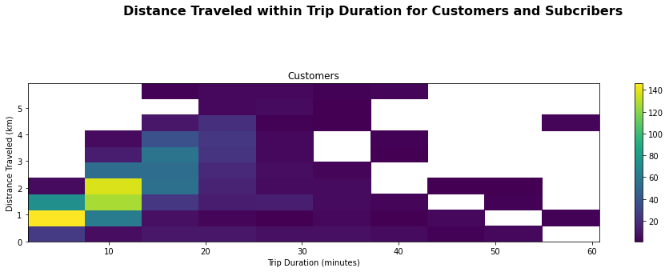

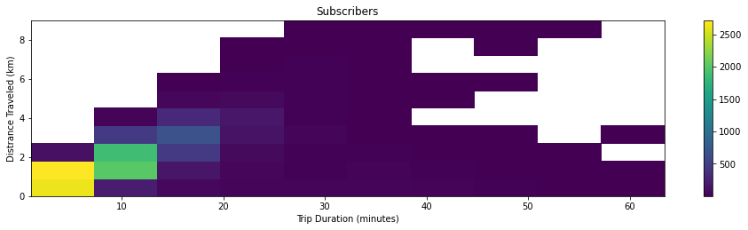

```python
plt.figure(figsize = (16,8));
plt.subplot(2, 1, 1)
customers = df.query('user_type == "Customer"')
plt.hist2d(data = customers, x = 'duration_min', y = 'dist', cmin =.5)
plt.colorbar()
plt.ylabel("Distrance Traveled (km)");
plt.xlabel('Trip Duration (minutes)');
plt.title('Customers');

plt.suptitle('Distance Traveled within Trip Duration for Customers and Subcribers', y=1.05, fontsize=16, fontweight='bold');


plt.figure(figsize = (16,8));
plt.subplot(2, 1, 1)
Subscriber = df.query('user_type == "Subscriber"')
plt.hist2d(data = Subscriber, x = 'duration_min', y = 'dist', cmin =.5)
plt.colorbar()
plt.ylabel("Distrance Traveled (km)");
plt.xlabel('Trip Duration (minutes)');
plt.title('Subscribers');
```

> Most Distance Traveled and Trip Duration is very similar for each for across each gender. This isn't proof enough to show that distance traveled and trip duration is affected by member gender.

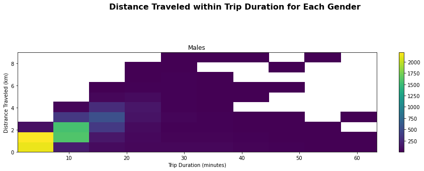

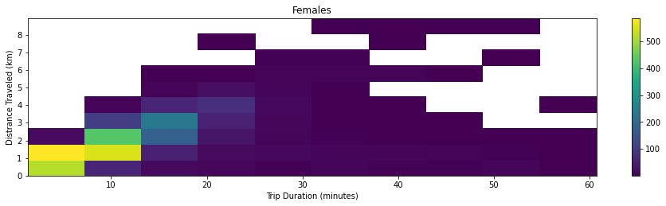

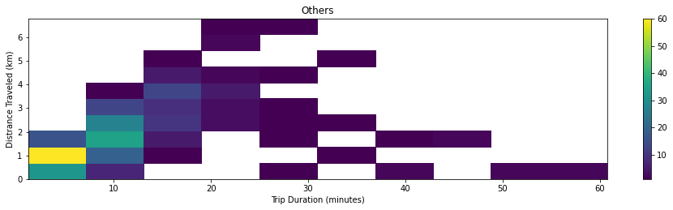

```python
plt.figure(figsize = (16,8));
plt.subplot(2, 1, 1)
Male = df.query('member_gender == "Male"')
plt.hist2d(data = Male, x = 'duration_min', y = 'dist', cmin =.5)
plt.colorbar()
plt.ylabel("Distrance Traveled (km)");
plt.xlabel('Trip Duration (minutes)');
plt.title('Males');

plt.suptitle('Distance Traveled within Trip Duration for Each Gender', y=1.05, fontsize=16, fontweight='bold');

plt.figure(figsize = (16,8));
plt.subplot(2, 1, 1)
Female = df.query('member_gender == "Female"')
plt.hist2d(data = Female, x = 'duration_min', y = 'dist', cmin =.5)
plt.colorbar()
plt.ylabel("Distrance Traveled (km)");
plt.xlabel('Trip Duration (minutes)');
plt.title('Females');


plt.figure(figsize = (16,8));
plt.subplot(2, 1, 1)
Other = df.query('member_gender == "Other"')
plt.hist2d(data = Other, x = 'duration_min', y = 'dist', cmin =.5)
plt.colorbar()
plt.ylabel("Distrance Traveled (km)");
plt.xlabel('Trip Duration (minutes)');
plt.title('Others');
```

## Ride Duration and Distrance Traveled across Member's Ages

> From investigation, it seems age-wise members over 60 didn't travel pass some minutes or distance. This shows that to some extent, age can affects distance traveled and trip duratance.

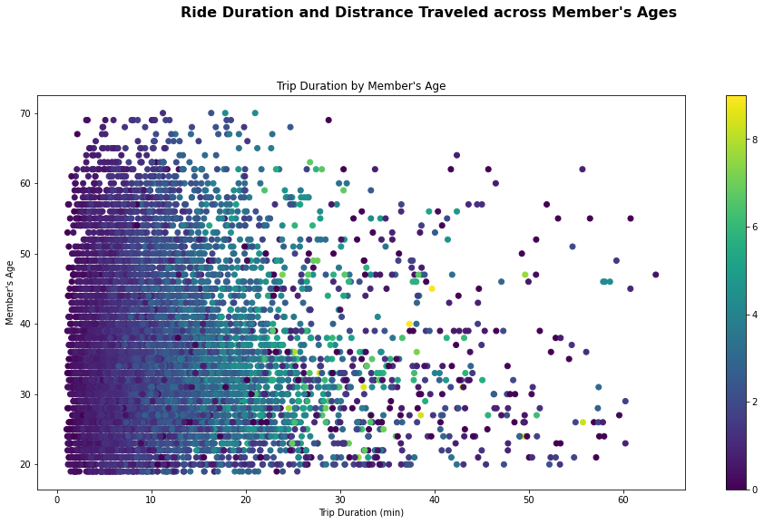

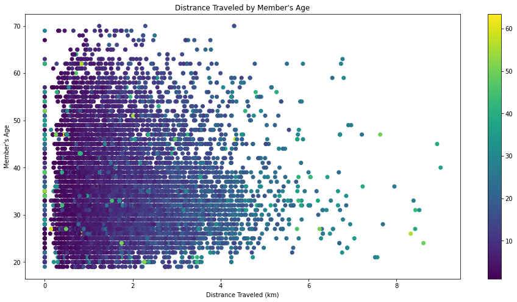

```python
plt.subplot
plt.figure(figsize = (16,8));
plt.scatter(data = df, c = 'dist', y = 'member_age', x = 'duration_min');
plt.colorbar();
plt.xlabel("Trip Duration (min)");
plt.ylabel("Member's Age");
plt.title("Trip Duration by Member's Age");

plt.suptitle("Ride Duration and Distrance Traveled across Member's Ages", y=1.05, fontsize=16, fontweight='bold');

plt.subplot
plt.figure(figsize = (16,8));
plt.scatter(data = df, x = 'dist', y = 'member_age', c = 'duration_min');
plt.colorbar();
plt.xlabel("Distrance Traveled (km)");
plt.ylabel("Member's Age");
plt.title("Distrance Traveled by Member's Age");
```

```python
!jupyter nbconvert Ford_Gobike_Data_Part_II.ipynb --to slides --post serve --no-input --no-prompt
```

[output not shown]